# p8105_hw6_kw3104

2024-12-02

```r
library(p8105.datasets)

library(broom)
library(ggplot2)
library(tidyverse)
library(boot)
library(knitr)
library(purrr)
library(modelr)
library(forcats)
library(dplyr)
library(stringr)
library(mgcv)
set.seed(1)
```

## Problem 1

```r
weather_df =
  rnoaa::meteo_pull_monitors(
    c("USW00094728"),
    var = c("PRCP", "TMIN", "TMAX"),
    date_min = "2017-01-01",
    date_max = "2017-12-31") |>
  mutate(
    name = recode(id, USW00094728 = "CentralPark_NY"),
    tmin = tmin / 10,
    tmax = tmax / 10) |>
  select(name, id, everything())
```

```
## using cached file: /Users/carriewww/Library/Caches/org.R-project.R/R/rnoaa/noaa_ghcnd/USW00094728.dly
```

```
## date created (size, mb): 2024-10-28 19:36:31.594818 (8.657)
```

```
## file min/max dates: 1869-01-01 / 2024-10-31
```

`weather_df` has 365 obs and 6 variables(name, id, data, prcp, tmax, tmin)

function

```r
bootstrap_analysis <- function(data, indices) {
  bootstrap_sample <- data[indices, ]

  # Fit the regression model
  bootstrap_fit <- lm(tmax ~ tmin, data = weather_df)

  # Extract R-squared using broom::glance()
  r_squared <- broom::glance(bootstrap_fit)$r.squared

  # Extract coefficients using broom::tidy() and compute log(beta_0 * beta_1)
  coefs <- broom::tidy(bootstrap_fit) |>
    filter(term %in% c("(Intercept)", "tmin")) |>
    pull(estimate)
  log_beta_product <- log(coefs[1] * coefs[2])


  return(c(r_squared = r_squared, log_beta_product = log_beta_product))
}
```

- r-squared = 0.912
- beta 1 = 7.21, beta 2 = 1.04

Perform 5000 bootstrap resamples

```r
bootstrap_results <- boot(
  data = weather_df,
  statistic = function(data, indices) unlist(bootstrap_analysis(data, indices)),
  R = 5000
)

# Transform bootstrap results into a tibble
bootstrap_df <- as_tibble(bootstrap_results$t) |>
  rename(r_squared = V1, log_beta_product = V2)
```

r squared

[figure not shown]

```r
r_squared_plot <- bootstrap_df |>
  ggplot(aes(x = r_squared)) +
  geom_density(fill = "blue", alpha = 0.5) +
  labs(title = "Bootstrap Distribution of R-squared",
       x = "R-squared", y = "Density")

r_squared_plot
```

log beta

[figure not shown]

```r
log_beta_plot <- bootstrap_df |>
  ggplot(aes(x = log_beta_product)) +
  geom_density(fill = "red", alpha = 0.5) +
  labs(title = "Bootstrap Distribution of log(beta_0 * beta_1)",
       x = "log(beta_0 * beta_1)", y = "Density")

log_beta_plot
```

```r
 # Compute 95% confidence intervals
ci_r_squared <- quantile(bootstrap_df$r_squared, probs = c(0.025, 0.975))
ci_log_beta_product <- quantile(bootstrap_df$log_beta_product, probs = c(0.025, 0.975))

# Create a data frame for confidence intervals
ci_df <- data.frame(
  Metric = c("R-squared", "log(beta_0 * beta_1)"),
  Lower_2.5_Quantile = c(ci_r_squared[1], ci_log_beta_product[1]),
  Upper_97.5_Quantile = c(ci_r_squared[2], ci_log_beta_product[2])
)

# Display the table using kable
kable(ci_df, caption = "95% Confidence Intervals for Bootstrap Estimates")
```

95% Confidence Intervals for Bootstrap Estimates

| Metric | Lower_2.5_Quantile | Upper_97.5_Quantile |
| --- | --- | --- |
| R-squared | 0.9115425 | 0.9115425 |
| log(beta_0 * beta_1) | 2.0137519 | 2.0137519 |

## Problem 2

```r
# Load data
url = "https://raw.githubusercontent.com/washingtonpost/data-homicides/master/homicide-data.csv"
homicide_data = read_csv(url)
```

- `homicide_data` has 52179 obs and 12 variables (uid, reported_date, victim_last, victim_first, victim_race, victim_age, etc.)

```r
homicide_cleaned =
 homicide_data |>
  mutate(
    city_state = str_c(city, state, sep = ", "), # Combine city and state
    victim_age = as.numeric(victim_age),  # Ensure victim_age is numeric
    solved = case_when(
      disposition %in% c("Closed without arrest", "Open/No arrest") ~ 0,
      disposition == "Closed by arrest" ~ 1
    )
  ) |>
  filter(
    !(city_state %in% c("Dallas, TX", "Phoenix, AZ", "Kansas City, MO", "Tulsa, AL")), # Remove specified cities
    victim_race %in% c("White", "Black"), # Include only White or Black victims
    !is.na(victim_age)
  ) |>
  select(city_state, solved, victim_age, victim_sex, victim_race)
```

after clean the data, `homicide_cleaned` has 39403 obs and 5 variables (city_state, solved, victim_age, victim_sex, victim_race)

```r
# Fit the logistic regression model for Baltimore, MD
baltimore_glm =
  homicide_cleaned |>
  filter(city_state == "Baltimore, MD") |>
  glm(solved ~ victim_age + victim_sex + victim_race, family = binomial(), data = _)

# Extract and process results
baltimore_glm |>
  broom::tidy() |>
  mutate(
    OR = exp(estimate),
    CI_lower = exp(estimate - 1.96 * std.error),
    CI_upper = exp(estimate + 1.96 * std.error)
  ) |>
  filter(term == "victim_sexMale") |>
  select(OR, CI_lower, CI_upper) |>
  knitr::kable(digits = 3, caption = "Adjusted Odds Ratio for Male Victims vs Female Victims (Baltimore, MD)")
```

Adjusted Odds Ratio for Male Victims vs Female Victims (Baltimore, MD)

| OR | CI_lower | CI_upper |
| --- | --- | --- |
| 0.426 | 0.325 | 0.558 |

- adjusted OR is 0.426, 95% CI (0.325, 0.558)
- we are 95% confident the true adjusted OR lies between 0.325 and 0.558.
- after adjusting for victim age and victim race, the odds of solving homicides for male victims are 57.4% lower compared to female victims.
- (1−0.426)×100=57.4%

```r
# Ensure the data is grouped by city_state and nest the data
victim_MF <-
  homicide_cleaned |>
  nest(data = -city_state) |>  # Group and nest data by city_state
  mutate(
    models = map(data, ~ glm(solved ~ victim_age + victim_sex + victim_race,
                              family = binomial(), data = .x)),  # Fit logistic regression for each city
    tidy_models = map(models, broom::tidy)  # Extract model results
  ) |>
  select(city_state, tidy_models) |>  # Keep relevant columns
  unnest(cols = tidy_models) |>  # Unnest the tidy model results
  mutate(
    OR = exp(estimate),  # Calculate Odds Ratio
    CI_lower = exp(estimate - 1.96 * std.error),  # Lower CI bound
    CI_upper = exp(estimate + 1.96 * std.error)   # Upper CI bound
  ) |>
  filter(term == "victim_sexMale") |>  # Filter results for male vs female victims
  select(city_state, OR, CI_lower, CI_upper)  # Select relevant columns

# Display the first 5 results as a table
victim_MF |>
  slice(1:5) |>
  knitr::kable(digits = 4, caption = "Adjusted Odds Ratios for Male Victims vs Female Victims by City")
```

Adjusted Odds Ratios for Male Victims vs Female Victims by City

| city_state | OR | CI_lower | CI_upper |
| --- | --- | --- | --- |
| Albuquerque, NM | 1.7675 | 0.8307 | 3.7609 |
| Atlanta, GA | 1.0001 | 0.6836 | 1.4631 |
| Baltimore, MD | 0.4255 | 0.3246 | 0.5579 |
| Baton Rouge, LA | 0.3814 | 0.2093 | 0.6953 |
| Birmingham, AL | 0.8700 | 0.5743 | 1.3180 |

`victim_MF` has 47 obs and 4 variables (city_state, OR, CI_lower, CI_upper)

plot

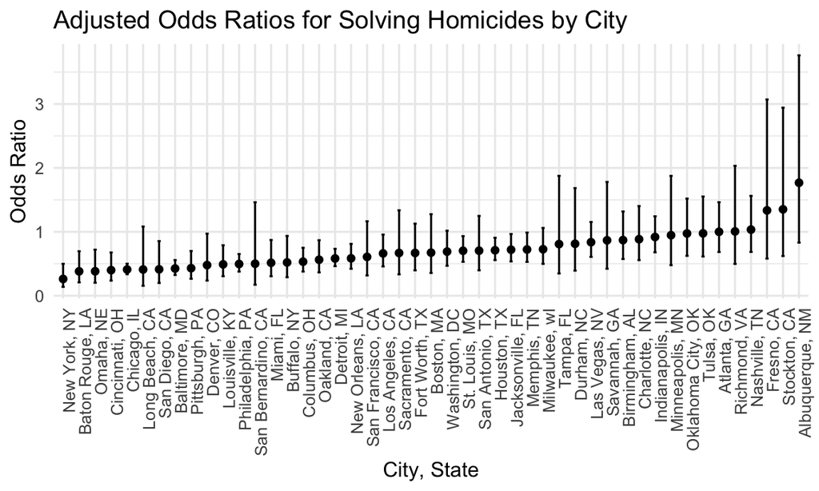

```r
# Plot the ORs and CIs
or_plot <- victim_MF |>
  mutate(city_state = fct_reorder(city_state, OR)) |>  # Reorder cities by estimated OR
  ggplot(aes(x = city_state, y = OR)) +
  geom_point() +  # Plot the point estimates for ORs
  geom_errorbar(aes(ymin = CI_lower, ymax = CI_upper), width = 0.2) +  # Add CIs
  labs(
    title = "Adjusted Odds Ratios for Solving Homicides by City",
    x = "City, State",
    y = "Odds Ratio"
  ) +
  theme_minimal() +
  theme(axis.text.x = element_text(angle = 90, hjust = 1))  # Rotate city labels for clarity

# Display the plot
print(or_plot)
```

## Problem 3

```r
# Load the dataset
birthweight <- read.csv("./data/birthweight.csv")

# Data cleaning and preparation using pipes
data_cleaned <- birthweight |>
  # Convert selected numeric columns to factors with proper labels
  mutate(
    BabySex = factor(babysex, levels = c(1, 2), labels = c("Male", "Female")),
    FatherRace = factor(frace, levels = c(1, 2, 3, 4, 8, 9),
                        labels = c("White", "Black", "Asian", "Puerto Rican", "Other", "Unknown")),
    MotherRace = factor(mrace, levels = c(1, 2, 3, 4, 8),
                        labels = c("White", "Black", "Asian", "Puerto Rican", "Other")),
    Malformations = factor(malform, levels = c(0, 1), labels = c("Absent", "Present")),
    Parity = as.factor(parity),
    PreviousLowBirthWeight = as.factor(pnumlbw),
    PreviousSmallGestationalAge = as.factor(pnumsga)
  ) %>%
  # Rename columns for clarity
  rename(
    HeadCircumference = bhead,
    BirthLength = blength,
    BirthWeight = bwt,
    MotherWeightAtDelivery = delwt,
    FamilyIncome = fincome,
    GestationalAgeWeeks = gaweeks,
    MotherMenarcheAge = menarche,
    MotherHeightInches = mheight,
    MotherAgeAtDelivery = momage,
    PrePregnancyBMI = ppbmi,
    PrePregnancyWeight = ppwt,
    CigarettesPerDay = smoken,
    WeightGainPregnancy = wtgain
  )

# Summarize the cleaned dataset
data_cleaned |>
  summary()
```

```
##     babysex      HeadCircumference  BirthLength     BirthWeight
##  Min.   :1.000   Min.   :21.00     Min.   :20.00   Min.   : 595
##  1st Qu.:1.000   1st Qu.:33.00     1st Qu.:48.00   1st Qu.:2807
##  Median :1.000   Median :34.00     Median :50.00   Median :3132
##  Mean   :1.486   Mean   :33.65     Mean   :49.75   Mean   :3114
##  3rd Qu.:2.000   3rd Qu.:35.00     3rd Qu.:51.00   3rd Qu.:3459
##  Max.   :2.000   Max.   :41.00     Max.   :63.00   Max.   :4791
##  MotherWeightAtDelivery  FamilyIncome       frace       GestationalAgeWeeks
##  Min.   : 86.0          Min.   : 0.00   Min.   :1.000   Min.   :17.70
##  1st Qu.:131.0          1st Qu.:25.00   1st Qu.:1.000   1st Qu.:38.30
##  Median :143.0          Median :35.00   Median :2.000   Median :39.90
##  Mean   :145.6          Mean   :44.11   Mean   :1.655   Mean   :39.43
##  3rd Qu.:157.0          3rd Qu.:65.00   3rd Qu.:2.000   3rd Qu.:41.10
##  Max.   :334.0          Max.   :96.00   Max.   :8.000   Max.   :51.30
##     malform         MotherMenarcheAge MotherHeightInches MotherAgeAtDelivery
##  Min.   :0.000000   Min.   : 0.00     Min.   :48.00      Min.   :12.0
##  1st Qu.:0.000000   1st Qu.:12.00     1st Qu.:62.00      1st Qu.:18.0
##  Median :0.000000   Median :12.00     Median :63.00      Median :20.0
##  Mean   :0.003455   Mean   :12.51     Mean   :63.49      Mean   :20.3
##  3rd Qu.:0.000000   3rd Qu.:13.00     3rd Qu.:65.00      3rd Qu.:22.0
##  Max.   :1.000000   Max.   :19.00     Max.   :77.00      Max.   :44.0
##      mrace           parity            pnumlbw     pnumsga  PrePregnancyBMI
##  Min.   :1.000   Min.   :0.000000   Min.   :0   Min.   :0   Min.   :13.07
##  1st Qu.:1.000   1st Qu.:0.000000   1st Qu.:0   1st Qu.:0   1st Qu.:19.53
##  Median :2.000   Median :0.000000   Median :0   Median :0   Median :21.03
##  Mean   :1.627   Mean   :0.002303   Mean   :0   Mean   :0   Mean   :21.57
##  3rd Qu.:2.000   3rd Qu.:0.000000   3rd Qu.:0   3rd Qu.:0   3rd Qu.:22.91
##  Max.   :4.000   Max.   :6.000000   Max.   :0   Max.   :0   Max.   :46.10
##  PrePregnancyWeight CigarettesPerDay WeightGainPregnancy   BabySex
##  Min.   : 70.0      Min.   : 0.000   Min.   :-46.00      Male  :2230
##  1st Qu.:110.0      1st Qu.: 0.000   1st Qu.: 15.00      Female:2112
##  Median :120.0      Median : 0.000   Median : 22.00
##  Mean   :123.5      Mean   : 4.145   Mean   : 22.08
##  3rd Qu.:134.0      3rd Qu.: 5.000   3rd Qu.: 28.00
##  Max.   :287.0      Max.   :60.000   Max.   : 89.00
##         FatherRace          MotherRace   Malformations  Parity
##  White       :2123   White       :2147   Absent :4327   0:4339
##  Black       :1911   Black       :1909   Present:  15   1:   1
##  Asian       :  46   Asian       :  43                  3:   1
##  Puerto Rican: 248   Puerto Rican: 243                  6:   1
##  Other       :  14   Other       :   0
##  Unknown     :   0
##  PreviousLowBirthWeight PreviousSmallGestationalAge
##  0:4342                 0:4342
##
##
##
##
##
```

```r
# Check for missing values
data_cleaned |>
  summarise(across(everything(), ~ sum(is.na(.)), .names = "missing_{col}"))
```

```
##   missing_babysex missing_HeadCircumference missing_BirthLength
## 1               0                         0                   0
##   missing_BirthWeight missing_MotherWeightAtDelivery missing_FamilyIncome
## 1                   0                              0                    0
##   missing_frace missing_GestationalAgeWeeks missing_malform
## 1             0                           0               0
##   missing_MotherMenarcheAge missing_MotherHeightInches
## 1                         0                          0
##   missing_MotherAgeAtDelivery missing_mrace missing_parity missing_pnumlbw
## 1                           0             0              0               0
##   missing_pnumsga missing_PrePregnancyBMI missing_PrePregnancyWeight
## 1               0                       0                          0
##   missing_CigarettesPerDay missing_WeightGainPregnancy missing_BabySex
## 1                        0                           0               0
##   missing_FatherRace missing_MotherRace missing_Malformations missing_Parity
## 1                  0                  0                     0              0
##   missing_PreviousLowBirthWeight missing_PreviousSmallGestationalAge
## 1                              0                                   0
```